# BurglaryBuildingFeatures

September 10, 2015

We take a subset of burglary data so that contains only 2008-2014 records to relieve computational burden. The regular grid is made by setting up a 120 $\times$ 160 grid then constraint it by keeping those inside the city boundary, in which 7724 grids are included.

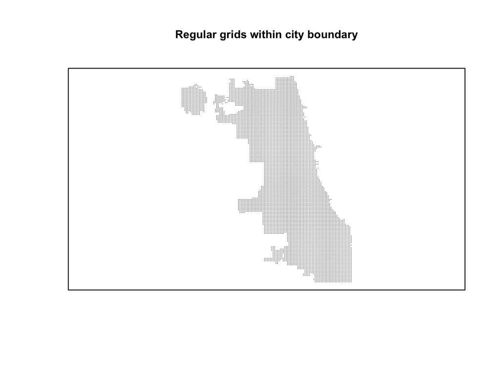

Due the extremely big building ground file size (~3GB), we do not plot it here.

If we could match buildings of each burglary, then we’d be able to find the associated building characteristics such as number of units. (Building shape file data has these attributes that might be useful: building status, stories, number of unit, year built, building square foot, building condition) Unfortunately, we can’t match the incident locations and buildings using a simple method. The following figures illustrate why. Plus, CPD’s crime data has street numbers and street names for most of the burglary incidents while building shape file doesn’t. Even if it had, it’d be very difficult to match text information using regular expression as texts are recorded in various formats.

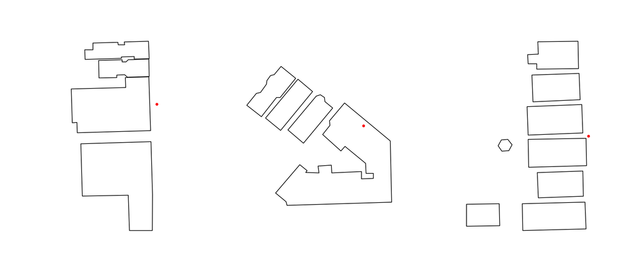

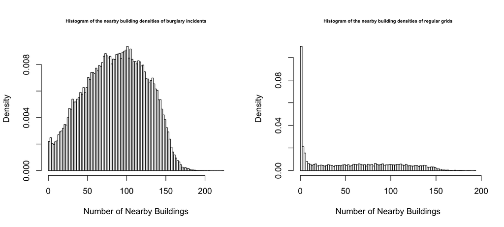